# STAT 400 Quiz 1

Justin Wininger

Due by 11:59 PM on Friday, Feb 14, 2025

## Front Matter

```r
library(tidyverse)
```

## Background Information

In a Poisson process, we are counting the number of events per unit of time or space and the number of events depends only on the length or size of the interval. As an example, we might want to know how many customers go through the drive-thru at Starbucks between 10 and 11 AM. We can then model $Y$, the number of events in one of these sections with the Poisson distribution, which is often used for modeling counts. The Poisson probability mass function (PMF) is given by:

$$P(Y=y \mid \lambda) =
\frac{e^{-\lambda}\cdot \lambda^y}{y!} \hspace{2cm} \text{ for } y
= 0, 1, 2, \ldots$$

The Poisson distribution is characterized by the single parameter $\lambda$, which is the mean or expected count in the unit of time or space of interest. The value of $\lambda$ affects the shape of the distribution. **The goal of this activity is to understand how the value of $\lambda$ affects the shape of the distribution and how it relates to the mean and variance of the distribution.**

## Task 1

The code randomly generates 50,000 values from a Poisson distribution with parameter $\lambda = 0.5$ using the `rpois` function. (You can think of this as 50,000 random samples.) The plot that follows shows the empirical distribution of the 50,000 samples which approximates the shape of a Poisson distribution. In your markdown document, recreate the plot and answer the questions that follow:

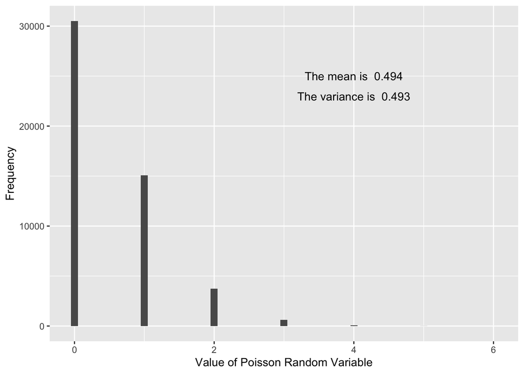

```r
#Generate a random sample
num_samples <- 50000
set.seed(123) #This random number seeds allows us to get the same "random" results
poisson_values <- rpois(n = num_samples, lambda = 0.5)
set.seed(NULL)

#Store data as data frame so it can be used with ggplot
df <- data.frame(X = poisson_values)

#Create Plot
ggplot(data = df, mapping = aes(x = X)) +
  geom_histogram(binwidth = 0.1) +
  annotate("text", x = 4, y = 25000, label= paste("The mean is ", round(mean(df$X), digits = 3))) +
  annotate("text", x = 4, y = 23000, label= paste("The variance is ", round(var(df$X), digits = 3))) +
  labs(y = "Frequency",
       x = "Value of Poisson Random Variable")
```

- What is the shape of the distribution? This distribution is very skewed to the right, but is the perfect shape for poisson regression.
- What do you notice about the relationship between the mean and variance of the samples and the value of the parameter, $\lambda$? The mean and variance are very similar and are for all intents and purposes equal, which is exactly what we want for poisson regression.

## Task 2

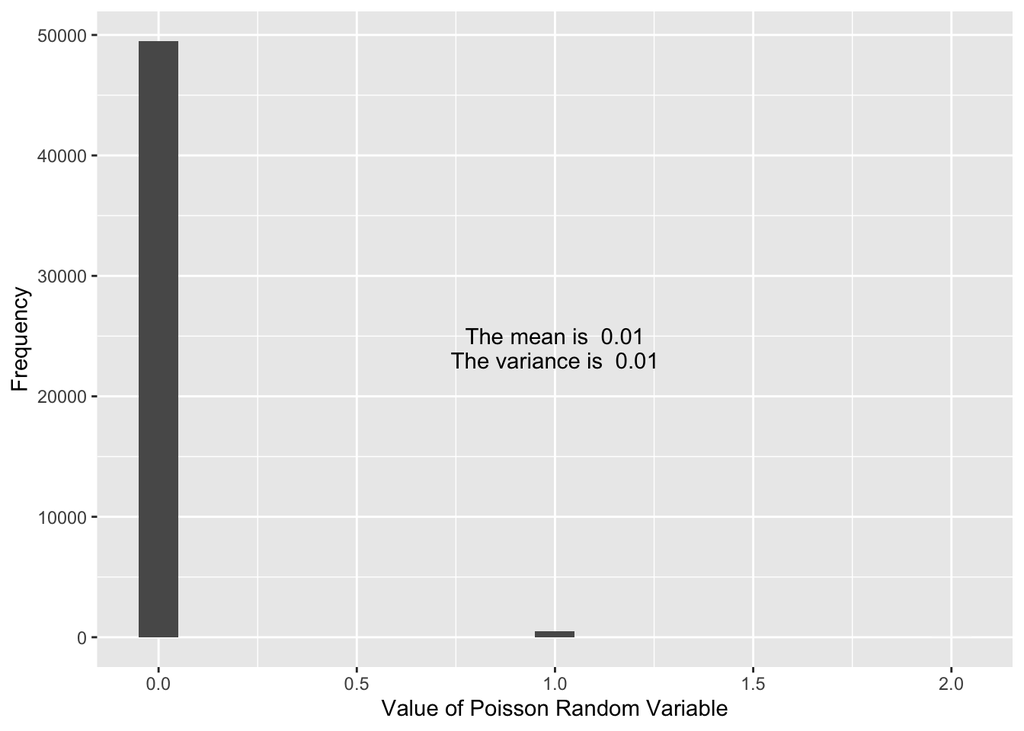

```r
#Generate a random sample
num_samples <- 50000
set.seed(123) #This random number seeds allows us to get the same "random" results
poisson_values <- rpois(n = num_samples, lambda = 0.01)
set.seed(NULL)

#Store data as data frame so it can be used with ggplot
df <- data.frame(X = poisson_values)

#Create Plot
ggplot(data = df, mapping = aes(x = X)) +
  geom_histogram(binwidth = 0.1) +
  annotate("text", x = 1, y = 25000, label= paste("The mean is ", round(mean(df$X), digits = 3))) +
  annotate("text", x = 1, y = 23000, label= paste("The variance is ", round(var(df$X), digits = 3))) +
  labs(y = "Frequency",
       x = "Value of Poisson Random Variable")
```

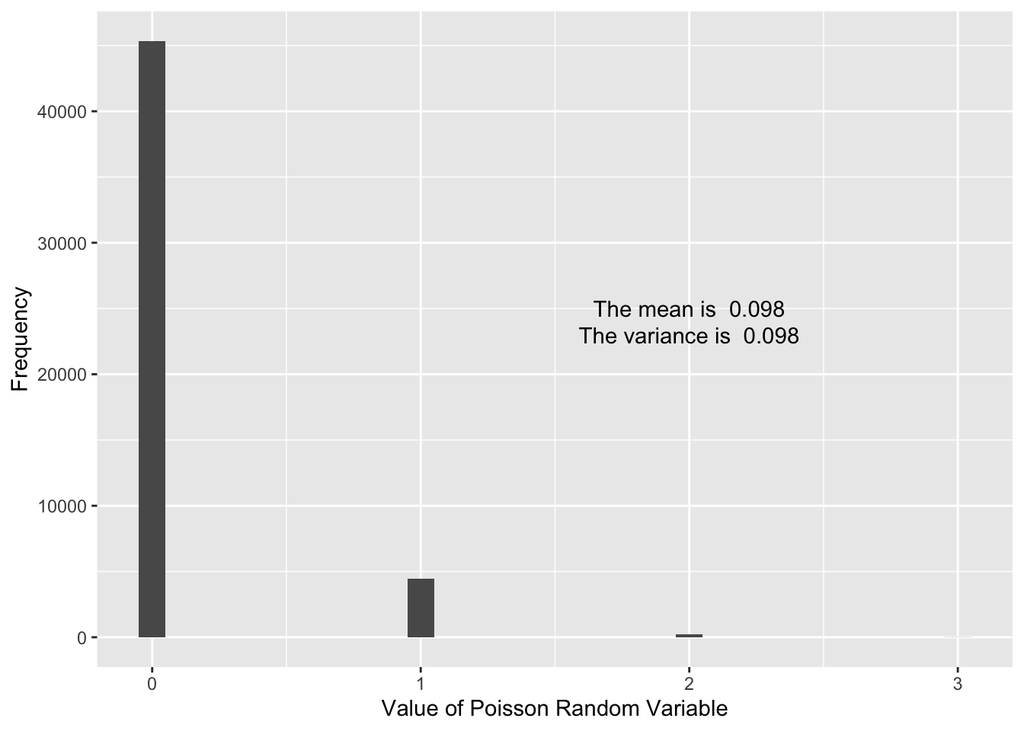

```r
#Generate a random sample
num_samples <- 50000
set.seed(123) #This random number seeds allows us to get the same "random" results
poisson_values <- rpois(n = num_samples, lambda = 0.1)
set.seed(NULL)

#Store data as data frame so it can be used with ggplot
df <- data.frame(X = poisson_values)

#Create Plot
ggplot(data = df, mapping = aes(x = X)) +
  geom_histogram(binwidth = 0.1) +
  annotate("text", x = 2, y = 25000, label= paste("The mean is ", round(mean(df$X), digits = 3))) +
  annotate("text", x = 2, y = 23000, label= paste("The variance is ", round(var(df$X), digits = 3))) +
  labs(y = "Frequency",
       x = "Value of Poisson Random Variable")
```

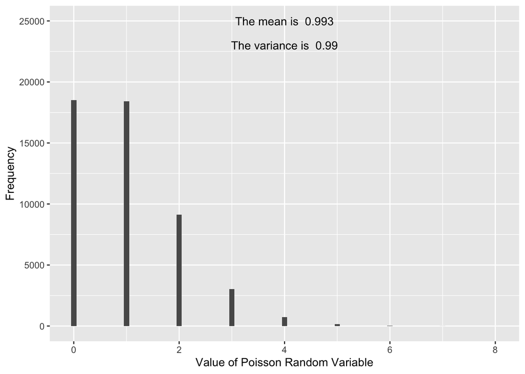

```r
#Generate a random sample
num_samples <- 50000
set.seed(123) #This random number seeds allows us to get the same "random" results
poisson_values <- rpois(n = num_samples, lambda = 1)
set.seed(NULL)

#Store data as data frame so it can be used with ggplot
df <- data.frame(X = poisson_values)

#Create Plot
ggplot(data = df, mapping = aes(x = X)) +
  geom_histogram(binwidth = 0.1) +
  annotate("text", x = 4, y = 25000, label= paste("The mean is ", round(mean(df$X), digits = 3))) +
  annotate("text", x = 4, y = 23000, label= paste("The variance is ", round(var(df$X), digits = 3))) +
  labs(y = "Frequency",
       x = "Value of Poisson Random Variable")
```

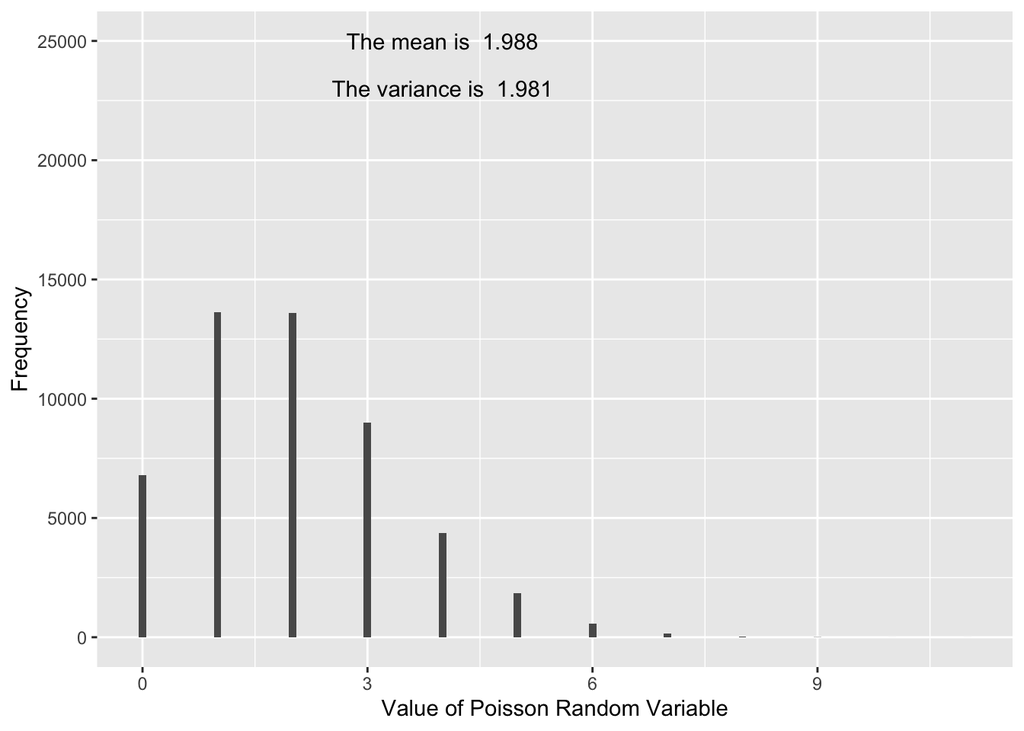

```r
#Generate a random sample
num_samples <- 50000
set.seed(123) #This random number seeds allows us to get the same "random" results
poisson_values <- rpois(n = num_samples, lambda = 2)
set.seed(NULL)

#Store data as data frame so it can be used with ggplot
df <- data.frame(X = poisson_values)

#Create Plot
ggplot(data = df, mapping = aes(x = X)) +
  geom_histogram(binwidth = 0.1) +
  annotate("text", x = 4, y = 25000, label= paste("The mean is ", round(mean(df$X), digits = 3))) +
  annotate("text", x = 4, y = 23000, label= paste("The variance is ", round(var(df$X), digits = 3))) +
  labs(y = "Frequency",
       x = "Value of Poisson Random Variable")
```

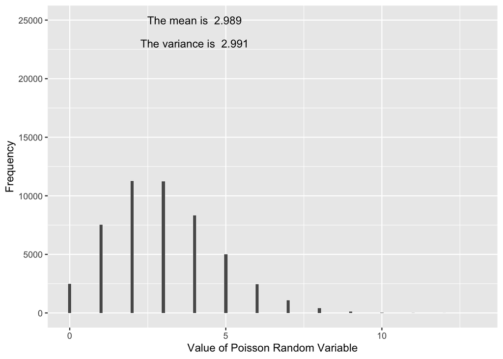

```r
#Generate a random sample
num_samples <- 50000
set.seed(123) #This random number seeds allows us to get the same "random" results
poisson_values <- rpois(n = num_samples, lambda = 3)
set.seed(NULL)

#Store data as data frame so it can be used with ggplot
df <- data.frame(X = poisson_values)

#Create Plot
ggplot(data = df, mapping = aes(x = X)) +
  geom_histogram(binwidth = 0.1) +
  annotate("text", x = 4, y = 25000, label= paste("The mean is ", round(mean(df$X), digits = 3))) +
  annotate("text", x = 4, y = 23000, label= paste("The variance is ", round(var(df$X), digits = 3))) +
  labs(y = "Frequency",
       x = "Value of Poisson Random Variable")
```

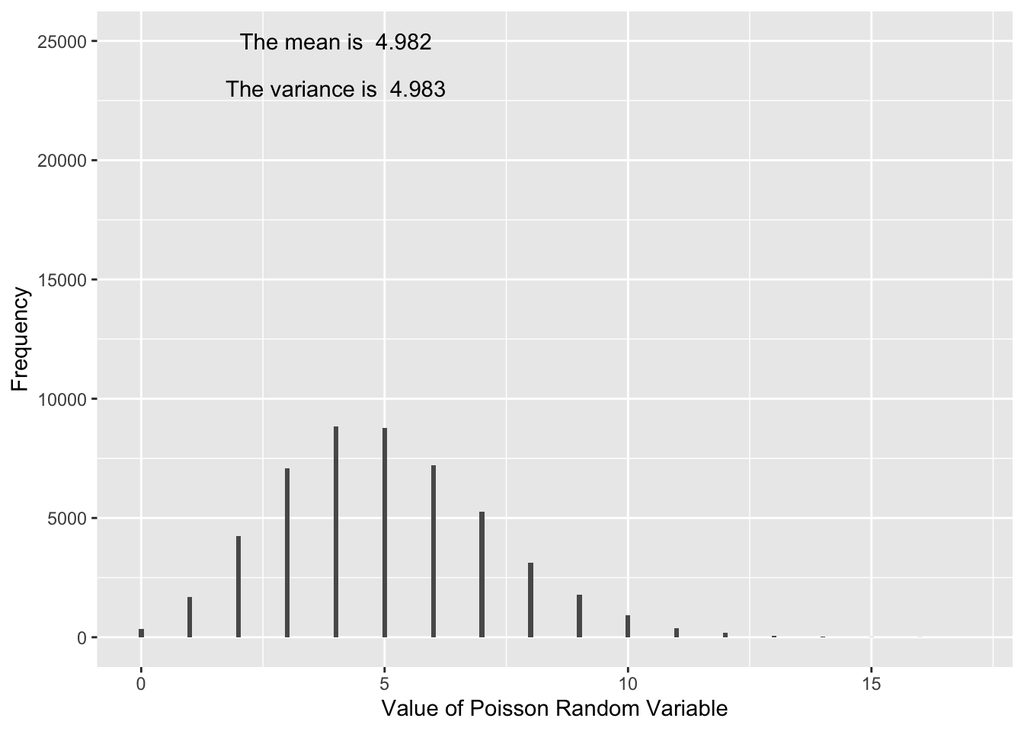

```r
#Generate a random sample
num_samples <- 50000
set.seed(123) #This random number seeds allows us to get the same "random" results
poisson_values <- rpois(n = num_samples, lambda = 5)
set.seed(NULL)

#Store data as data frame so it can be used with ggplot
df <- data.frame(X = poisson_values)

#Create Plot
ggplot(data = df, mapping = aes(x = X)) +
  geom_histogram(binwidth = 0.1) +
  annotate("text", x = 4, y = 25000, label= paste("The mean is ", round(mean(df$X), digits = 3))) +
  annotate("text", x = 4, y = 23000, label= paste("The variance is ", round(var(df$X), digits = 3))) +
  labs(y = "Frequency",
       x = "Value of Poisson Random Variable")
```

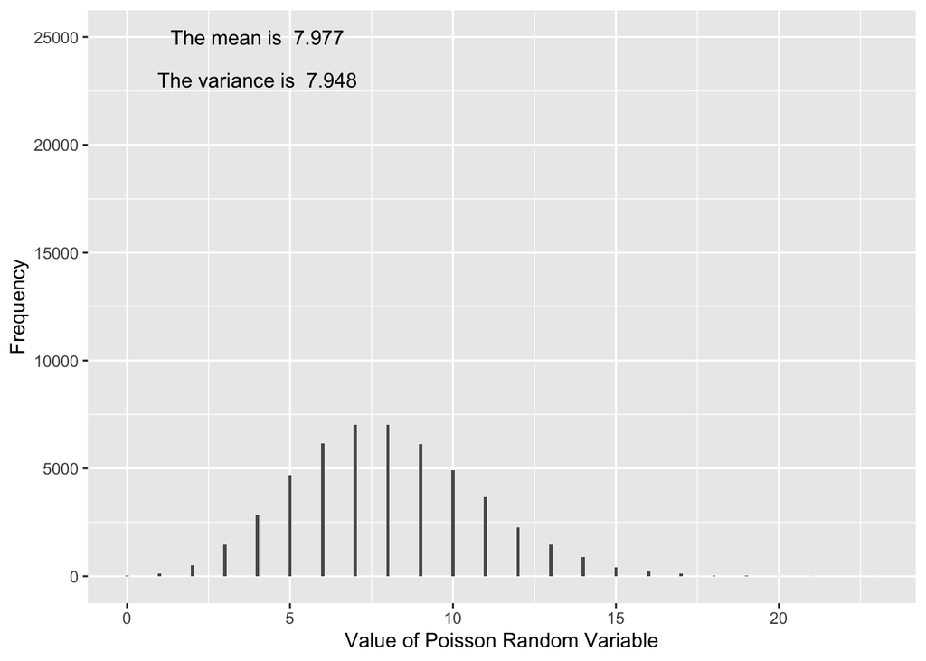

```r
#Generate a random sample
num_samples <- 50000
set.seed(123) #This random number seeds allows us to get the same "random" results
poisson_values <- rpois(n = num_samples, lambda = 8)
set.seed(NULL)

#Store data as data frame so it can be used with ggplot
df <- data.frame(X = poisson_values)

#Create Plot
ggplot(data = df, mapping = aes(x = X)) +
  geom_histogram(binwidth = 0.1) +
  annotate("text", x = 4, y = 25000, label= paste("The mean is ", round(mean(df$X), digits = 3))) +
  annotate("text", x = 4, y = 23000, label= paste("The variance is ", round(var(df$X), digits = 3))) +
  labs(y = "Frequency",
       x = "Value of Poisson Random Variable")
```

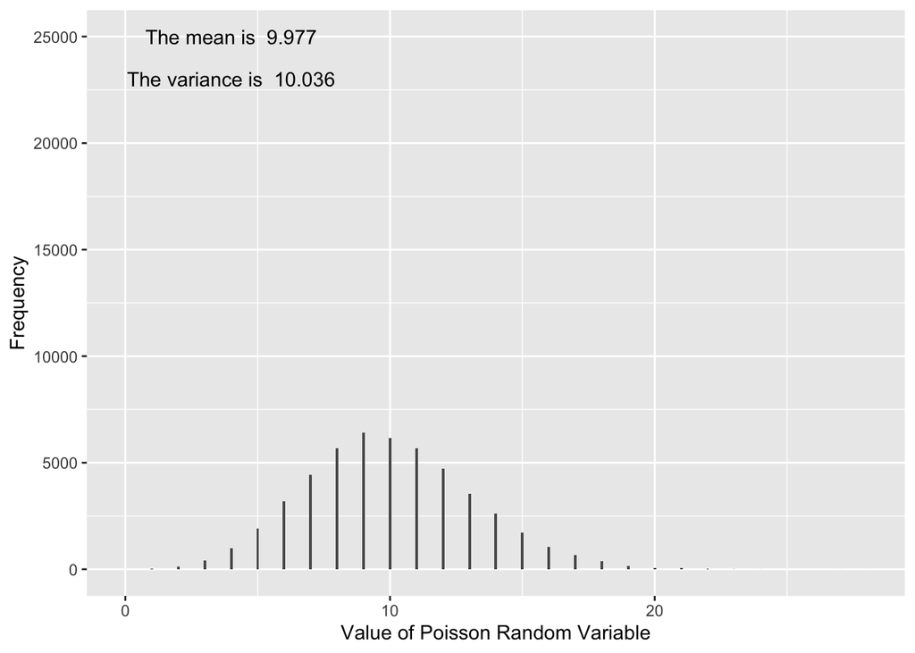

```r
#Generate a random sample
num_samples <- 50000
set.seed(123) #This random number seeds allows us to get the same "random" results
poisson_values <- rpois(n = num_samples, lambda = 10)
set.seed(NULL)

#Store data as data frame so it can be used with ggplot
df <- data.frame(X = poisson_values)

#Create Plot
ggplot(data = df, mapping = aes(x = X)) +
  geom_histogram(binwidth = 0.1) +
  annotate("text", x = 4, y = 25000, label= paste("The mean is ", round(mean(df$X), digits = 3))) +
  annotate("text", x = 4, y = 23000, label= paste("The variance is ", round(var(df$X), digits = 3))) +
  labs(y = "Frequency",
       x = "Value of Poisson Random Variable")
```

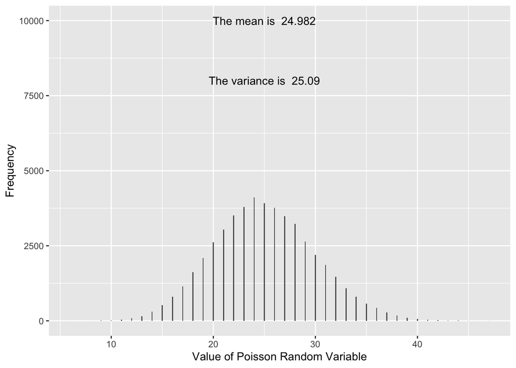

```r
num_samples <- 50000
set.seed(123) #This random number seeds allows us to get the same "random" results
poisson_values <- rpois(n = num_samples, lambda = 25)
set.seed(NULL)

#Store data as data frame so it can be used with ggplot
df <- data.frame(X = poisson_values)

#Create Plot
ggplot(data = df, mapping = aes(x = X)) +
  geom_histogram(binwidth = 0.1) +
  annotate("text", x = 25, y = 10000, label= paste("The mean is ", round(mean(df$X), digits = 3))) +
  annotate("text", x = 25, y = 8000, label= paste("The variance is ", round(var(df$X), digits = 3))) +
  labs(y = "Frequency",
       x = "Value of Poisson Random Variable")
```

Upon completing this activity, you should upload 2 items to Canvas: i.) your .Rmd file AND ii.) your .html file.